# FilteredChlorophyll_inspection_2014_2023

KKH

2023-12-05

This is the visual inspection script for Filtered Chlorophyll.

From ABP: This is a template to make your visual inspection script. It does not have to be an R Markdown but I like then especially the knit function so I can send the plots to coauthors. Make sure all of the columns get plotted even ones you think might not be that relevant.

## R Markdown Guide

**Read in Historical files from EDI**

```r
inUrl1  <- "https://pasta.lternet.edu/package/data/eml/edi/555/3/2f670c8316af634c76effdd205623912"
infile1 <- tempfile()
try(download.file(inUrl1,infile1,method="curl"))
if (is.na(file.size(infile1))) download.file(inUrl1,infile1,method="auto")

 historic <-read_csv(infile1)
```

**Read in L1 file** Set L1 file to NULL if not yet made. Need to change this to the GITHUB Link!!!

```r
L1 <- read_csv("~/GitHubRepos/CareyLabVT/Reservoirs/Data/DataNotYetUploadedToEDI/Raw_chla/Filt_chla_L1.csv")
```

**Bind historic and L1 files together**

```r
all_chla <- dplyr::bind_rows(historic, L1)
```

**Check there are no NAs in Flag columns** This section checks to make sure each observation has a data flag. It also checks to make sure the frequency of flags matches what we expect to see. There should be no NAs.

```r
#make sure no NAS in the Flag columns
Flags=all_chla%>%
  select(DateTime, starts_with("Flag"))

RowsNA=Flags[!complete.cases(Flags), ] # Keep only the complete rows

#check the flag column
Flags=all_chla%>%
  select(starts_with("Flag"))

# Make a table with the number of times a flag was used
for(f in 1:(ncol(Flags))){
  #print(colnames(Flags[f]))
  print(table(Flags[,f], useNA = "always"))
}
```

```
## Flag_Chla_ugL
##    0    1    2    3    4    5 <NA>
##  916   34    3   21   22   18    0
## Flag_Pheo_ugL
##    0    1    2    3    4    5   45 <NA>
##  544   22  278   21  131   17    1    0
```

**Manipulate Dataset for Plotting** Add Year, Month, and Day of Year for plotting. Add depth groups.

```r
# Altering dataset in order to plot stats
chla_YMD <- all_chla %>%
  mutate(Year = year(DateTime)) %>%
  mutate(Month = month(DateTime)) %>%
  mutate(DOY = yday(DateTime)) %>%
  mutate(Depth_group = ifelse(Depth_m == 0.1, "surface", ifelse(Depth_m > 0.1 & Depth_m < 4,"epi","hypo")))

#make plots of the data by reservoir and year
#this is a check to make sure that we have all of the data in the years that we expect to have it
head(chla_YMD)
```

```
## # A tibble: 6 × 12
##   Reservoir  Site DateTime            Depth_m Chla_ugL Pheo_ugL Flag_Chla_ugL
##   <chr>     <dbl> <dttm>                <dbl>    <dbl>    <dbl>         <dbl>
## 1 GWR          50 2014-04-18 12:00:00     0.1      6.3       NA             0
## 2 GWR          50 2014-04-18 12:00:00     5        5.8       NA             0
## 3 GWR          50 2014-04-18 12:00:00    10        1.7       NA             0
## 4 CCR          50 2014-04-20 12:00:00     0.1      4         NA             0
## 5 CCR          50 2014-04-20 12:00:00     5        7.5       NA             0
## 6 CCR          50 2014-04-20 12:00:00    14        9.2       NA             0
## # ℹ 5 more variables: Flag_Pheo_ugL <dbl>, Year <dbl>, Month <dbl>, DOY <dbl>,
## #   Depth_group <chr>
```

**Time Series for entire data set - Chlorophyll a**

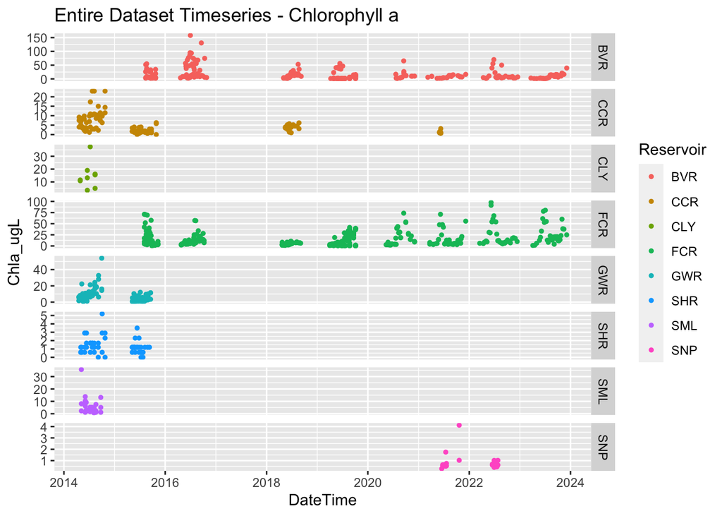

```r
# Facetted plot of the datapoints within each reservoir over the entire dataset
ggplot(subset(chla_YMD), aes(x = DateTime, y = Chla_ugL, col = Reservoir)) +
  geom_point(size = 1) +
  facet_grid(Reservoir ~., scales = "free_y") +
  ggtitle("Entire Dataset Timeseries - Chlorophyll a")
```

**Time Series for entire data set - Pheophyton**

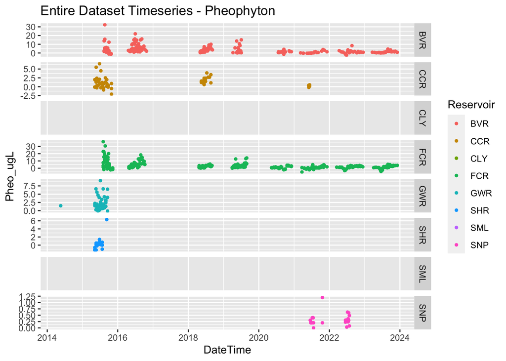

```r
# Facetted plot of the datapoints within each reservoir over the entire dataset
ggplot(subset(all_chla), aes(x = DateTime, y = Pheo_ugL, col = Reservoir)) +
  geom_point(size = 1) +
  facet_grid(Reservoir ~., scales = "free_y") +
  ggtitle("Entire Dataset Timeseries - Pheophyton")
```

**All Sites, All Years, Monthly Mean - Chlorophyll a**

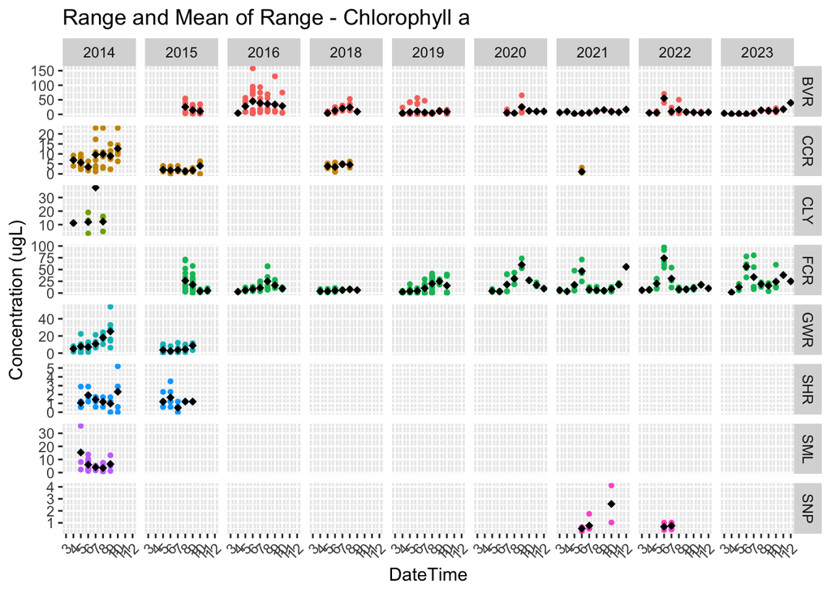

```r
# Facetted plot of the range of each reservoir for each year and the mean of the range
ggplot(subset(chla_YMD), aes(x = Month, y = Chla_ugL, col = Reservoir))+
  geom_point(size = 1) +
  #stat_summary(fun = "mean", geom = "point", pch = 0, size =2, color = 'black') +
  stat_summary(fun = "mean", geom = "point", pch = 18, size =2, color = 'black') +
  facet_grid(Reservoir~Year, scales = 'free_y') +
  scale_x_continuous("DateTime", breaks = seq(1, 12, 1)) +
  scale_y_continuous("Concentration (ugL)") +
  theme(axis.text.x = element_text(angle = 45, hjust = 1), legend.position = 'none') +
  ggtitle("Range and Mean of Range - Chlorophyll a")
```

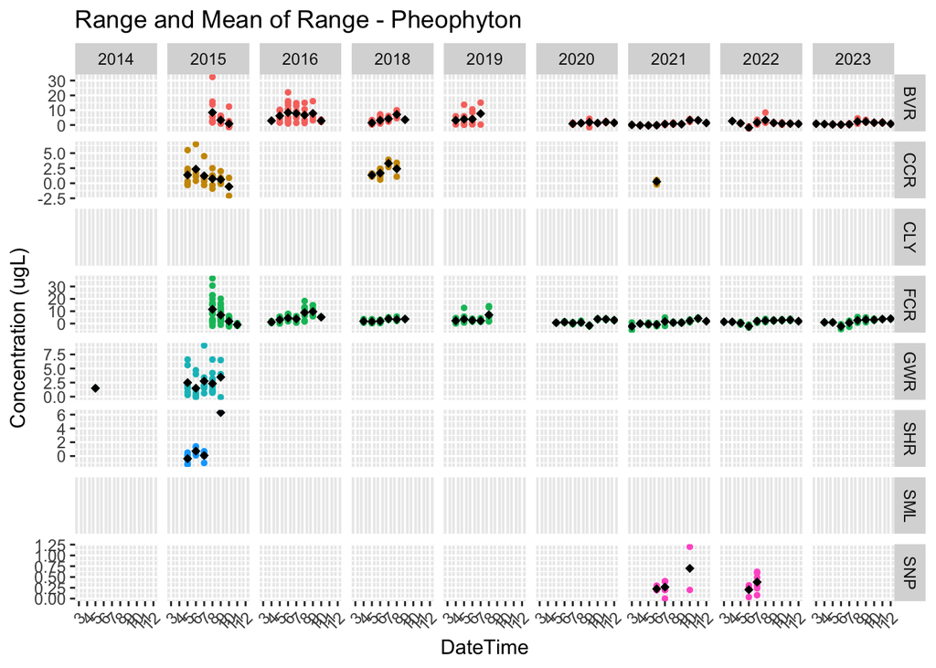

```r
# Facetted plot of the range of each reservoir for each year and the mean of the range
ggplot(subset(chla_YMD), aes(x = Month, y = Pheo_ugL, col = Reservoir))+
  geom_point(size = 1) +
  #stat_summary(fun = "mean", geom = "point", pch = 0, size =2, color = 'black') +
  stat_summary(fun = "mean", geom = "point", pch = 18, size =2, color = 'black') +
  #facet_grid(Year ~ Reservoir, scales = 'free_y') +
  facet_grid(Reservoir~Year, scales = 'free_y') +
  scale_x_continuous("DateTime", breaks = seq(1, 12, 1)) +
  scale_y_continuous("Concentration (ugL)") +
  theme(axis.text.x = element_text(angle = 45, hjust = 1), legend.position = 'none') +
  ggtitle("Range and Mean of Range - Pheophyton")
```

**All Sites, All Years, Monthly Median - Chlorophyll a**

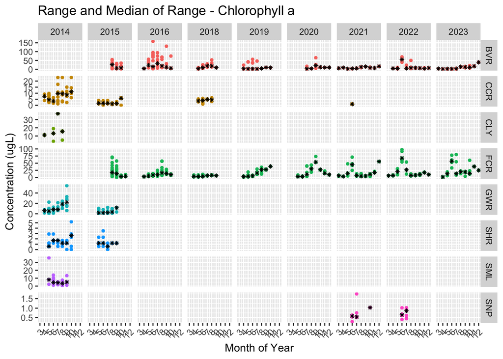

```r
# Facetted plot of the range of each reservoir for each year and the median of the range
ggplot(subset(chla_YMD, Site == 50), aes(x = Month, y = Chla_ugL, col = Reservoir))+
  geom_point(size = 1) +
  stat_summary(fun = "median", geom = "point", pch = 8, size = 1, color = 'black') +
  facet_grid(Reservoir~Year, scales = 'free_y') +
  #scale_x_continuous("DateTime", breaks = seq(2014,2022, 1)) +
  scale_x_continuous("Month of Year", breaks = seq(1,12, 1)) +
  scale_y_continuous("Concentration (ugL)") +
  theme(axis.text.x = element_text(angle = 45, hjust = 1), legend.position = 'none') +
  ggtitle("Range and Median of Range - Chlorophyll a")
```

**All Sites, All Years, Monthly Median - Pheophyton**

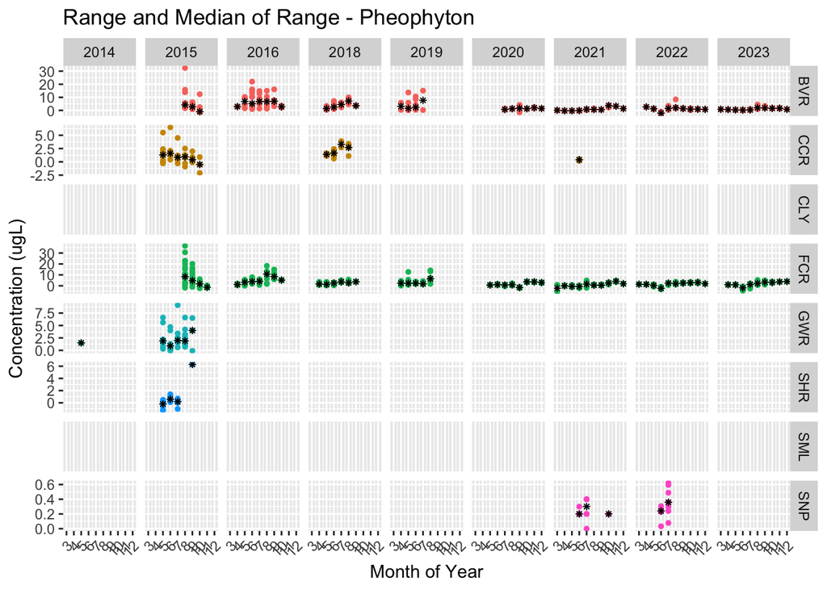

```r
# Facetted plot of the range of each reservoir for each year and the median of the range
ggplot(subset(chla_YMD, Site == 50), aes(x = Month, y = Pheo_ugL, col = Reservoir))+
  geom_point(size = 1) +
  stat_summary(fun = "median", geom = "point", pch = 8, size = 1, color = 'black') +
  facet_grid(Reservoir~Year, scales = 'free_y') +
  #scale_x_continuous("DateTime", breaks = seq(2014,2022, 1)) +
  scale_x_continuous("Month of Year", breaks = seq(1,12, 1)) +
  scale_y_continuous("Concentration (ugL)") +
  theme(axis.text.x = element_text(angle = 45, hjust = 1), legend.position = 'none') +
  ggtitle("Range and Median of Range - Pheophyton")
```

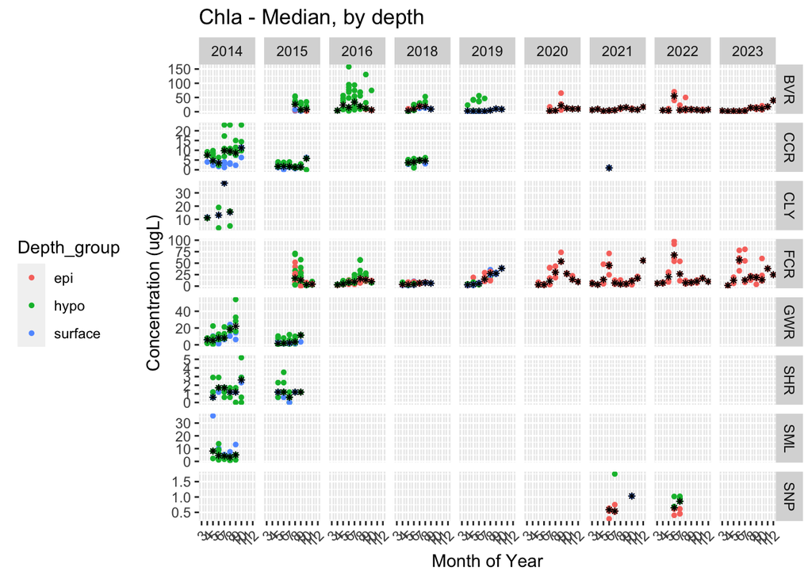

```r
# Facetted plot of the range of each reservoir for each year and the median of the range with depth
ggplot(subset(chla_YMD, Site == 50), aes(x = Month, y = Chla_ugL, col = Depth_group))+
  geom_point(size = 1) +
  stat_summary(fun = "median", geom = "point", pch = 8, size = 1, color = 'black') +
  facet_grid(Reservoir~Year, scales = 'free_y') +
  #scale_x_continuous("DateTime", breaks = seq(2014,2022, 1)) +
  scale_x_continuous("Month of Year", breaks = seq(1,12, 1)) +
  scale_y_continuous("Concentration (ugL)") +
  theme(axis.text.x = element_text(angle = 45, hjust = 1), legend.position = 'left') +
  ggtitle("Chla - Median, by depth")
```

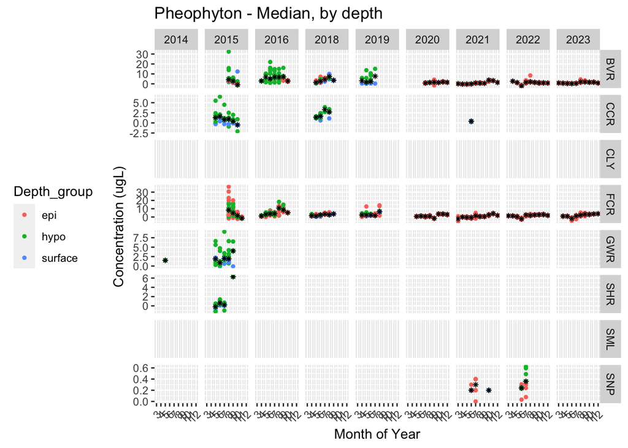

```r
# Facetted plot of the range of each reservoir for each year and the median of the range with depth
ggplot(subset(chla_YMD, Site == 50), aes(x = Month, y = Pheo_ugL, col = Depth_group))+
  geom_point(size = 1) +
  stat_summary(fun = "median", geom = "point", pch = 8, size = 1, color = 'black') +
  facet_grid(Reservoir~Year, scales = 'free_y') +
  #scale_x_continuous("DateTime", breaks = seq(2014,2022, 1)) +
  scale_x_continuous("Month of Year", breaks = seq(1,12, 1)) +
  scale_y_continuous("Concentration (ugL)") +
  theme(axis.text.x = element_text(angle = 45, hjust = 1), legend.position = 'left') +
  ggtitle("Pheophyton - Median, by depth")
```

**Flags** attributeName code definition Flag_Chla_ugL 0 Value acceptable. No flag  
Flag_Chla_ugL 1 Sample below detection  
Flag_Chla_ugL 2 Sample not taken  
Flag_Chla_ugL 3 Duplicate check failed  
Flag_Chla_ugL 4 Pigment in extract below detection (<34 ug/L)  
Flag_Chla_ugL 5 Duplicate values were averaged

```r
#subset data to FCR and BVR
chla_current <- chla_YMD %>%
  subset((Year=="2023")) %>%
   mutate(DOY = yday(DateTime))

head(chla_current)
```

```
## # A tibble: 6 × 12
##   Reservoir  Site DateTime            Depth_m Chla_ugL Pheo_ugL Flag_Chla_ugL
##   <chr>     <dbl> <dttm>                <dbl>    <dbl>    <dbl>         <dbl>
## 1 BVR          50 2023-03-21 12:00:00     1.6    3.09     0.866             1
## 2 FCR          50 2023-04-04 12:00:00     1.6    1.15     0.779             1
## 3 BVR          50 2023-04-13 12:00:00     1.6    1.20     0.653             1
## 4 FCR          50 2023-04-18 12:00:00     1.6    1.72     1.17              0
## 5 BVR          50 2023-05-01 12:00:00     1.6    0.764    0.199             1
## 6 FCR          50 2023-05-01 12:00:00     1.6    6.01     1.20              0
## # ℹ 5 more variables: Flag_Pheo_ugL <dbl>, Year <dbl>, Month <dbl>, DOY <dbl>,
## #   Depth_group <chr>
```

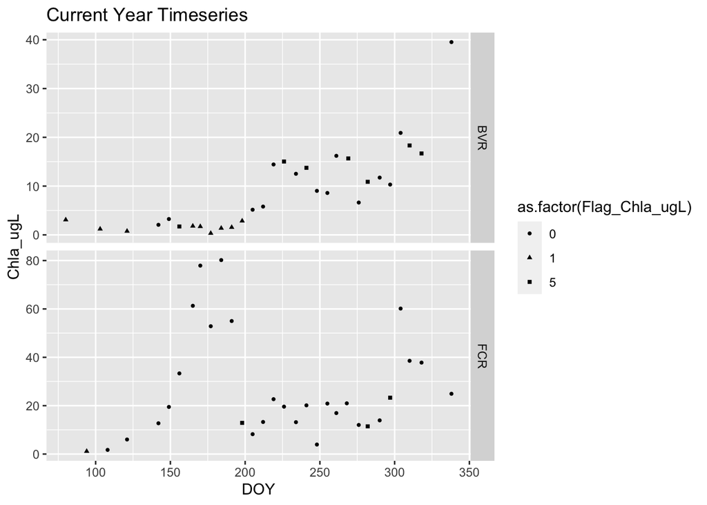

```r
#### Graph ####
# Current Year Timeseries
ggplot(subset(chla_current), aes(x = DOY, y = Chla_ugL, pch = as.factor(Flag_Chla_ugL))) +
  geom_point(size = 1) +
  facet_grid(Reservoir ~., scales = "free_y") +
  ggtitle("Current Year Timeseries")
```

**Flags** Flag_Pheo_ugL 0 Value acceptable. No flag  
Flag_Pheo_ugL 1 Sample below detection  
Flag_Pheo_ugL 2 Sample not taken  
Flag_Pheo_ugL 3 Duplicate check failed  
Flag_Pheo_ugL 4 Pigment in extract below detection (<34 ug/L)  
Flag_Pheo_ugL 45 Pigment in extract below detection (<34 ug/L) and duplicate values were averaged  
Flag_Pheo_ugL 5 Duplicate values were averaged

```r
#subset data to FCR and BVR
chla_current <- chla_YMD %>%
  subset((Year=="2023")) %>%
   mutate(DOY = yday(DateTime))

head(chla_current)
```

```
## # A tibble: 6 × 12
##   Reservoir  Site DateTime            Depth_m Chla_ugL Pheo_ugL Flag_Chla_ugL
##   <chr>     <dbl> <dttm>                <dbl>    <dbl>    <dbl>         <dbl>
## 1 BVR          50 2023-03-21 12:00:00     1.6    3.09     0.866             1
## 2 FCR          50 2023-04-04 12:00:00     1.6    1.15     0.779             1
## 3 BVR          50 2023-04-13 12:00:00     1.6    1.20     0.653             1
## 4 FCR          50 2023-04-18 12:00:00     1.6    1.72     1.17              0
## 5 BVR          50 2023-05-01 12:00:00     1.6    0.764    0.199             1
## 6 FCR          50 2023-05-01 12:00:00     1.6    6.01     1.20              0
## # ℹ 5 more variables: Flag_Pheo_ugL <dbl>, Year <dbl>, Month <dbl>, DOY <dbl>,
## #   Depth_group <chr>
```

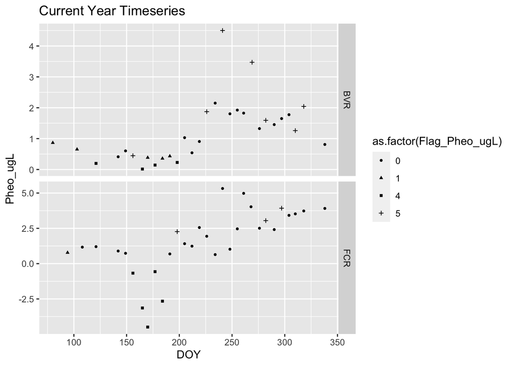

[output not shown]

```r
#### Graph ####
# Current Year Timeseries
ggplot(subset(chla_current), aes(x = DOY, y = Pheo_ugL, pch = as.factor(Flag_Pheo_ugL))) +
  geom_point(size = 1) +
  facet_grid(Reservoir ~., scales = "free_y") +
  ggtitle("Current Year Timeseries")
```

Make site description file

```r
 # These lines of code make the csv of the site descriptions with lat and long
  # Use Gsheet because you don't need to authenticate it.
 sites <- gsheet::gsheet2tbl("https://docs.google.com/spreadsheets/d/1TlQRdjmi_lzwFfQ6Ovv1CAozmCEkHumDmbg_L4A2e-8/edit#gid=1244423834")
 #data<- read_csv("YOUR DATA.csv")# Use this if you read in a csv
 #data <- current_df #This is the line you need to modify!
 trim_sites = function(data,sites){
   data_res_site=data%>% #Create a Reservoir/Site combo column
     mutate(res_site = trimws(paste0(Reservoir,Site)))
   sites_merged = sites%>% #Filter to Sites that are in the dataframe
     mutate(res_site = trimws(paste0(Reservoir,Site)))%>%
     filter(res_site%in%data_res_site$res_site)%>%
     select(-res_site)
 }
 sites_trimmed = trim_sites(data,sites)
 write.csv(sites_trimmed,"site_descriptions.csv", row.names=F)# Write to file
```